# Tutorial 05: Procesar Datos y Crear Gráficas

Los colores de las líneas se asignarán automáticamente por `ggplot` usando los colores por defecto del paquete, pero puedes cambiar estos colores usando la función `scale_color_manual()`:

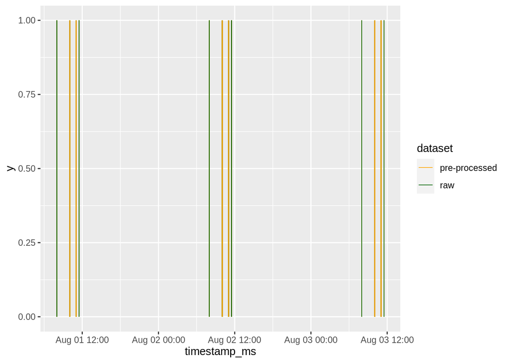

```r
ggplot(data = rfid_combined) +

  # Añade una línea vertical para cada marca de tiempo
  geom_segment(
    aes(x = timestamp_ms, y = 0, xend = timestamp_ms, yend = 1, color = dataset),
    linewidth = 0.3
  ) +

  scale_color_manual(values = c("orange", "darkgreen"))
```

Las líneas ahora tienen los colores nuevos que especificaste pero en la leyenda los datos procesados salen primero. Si quieres cambiar el orden de las etiquetas del conjunto de datos en la leyenda, y los colores asignados a los conjuntos de datos, puedes modificar la columna `dataset` en el `dataframe` que usaste para crear la gráfica.

Las funciones de `ggplot` usan un tipo de datos que se llaman `factors` para automáticamente determinar la estética de la gráfica, como el método de asignar colores que usaste arriba con `geom_segment()`. Las columnas (o vectores) en formato `factor` se ven como columnas de tipo `character` (en que cada fila contiene una secuencia de caracteres), pero R guarda los valores únicos de cada columna como números enteros y luego guarda los valores únicos de las secuencias de caracteres en una propiedad que se llama `levels` (“niveles” o “categorías”). Puedes cambiar el orden en que los valores únicos de una columna en formato `factor` se añaden a la gráfica cuando cambias el orden de los `levels` de la columna:

```r
# Cambia la columna dataset al tipo de datos "factor"
# Cuando especificas que el valor de "raw" ("original") venga primero en el argumento de levels, estás reorganizando los levels (niveles) de la columna para que este valor salga primero en la leyenda
rfid_combined <- rfid_combined %>%
  dplyr::mutate(
    dataset = factor(dataset, levels = c("raw", "pre-processed"))
  )

# La columna de dataset ahora es tipo "fct" o "factor"
glimpse(rfid_combined)
```

```
## Rows: 69
## Columns: 4
## $ sensor_id    <chr> "RFID", "RFID", "RFID", "RFID", "RFID", "RFID", "RFID", "…
## $ day          <int> 1, 1, 1, 1, 1, 1, 1, 1, 1, 1, 1, 1, 1, 1, 1, 1, 1, 1, 1, …
## $ timestamp_ms <dttm> 2023-08-01 08:00:00, 2023-08-01 08:00:00, 2023-08-01 08:…
## $ dataset      <fct> raw, pre-processed, raw, raw, pre-processed, raw, raw, pr…
```

```r
# Los niveles de la columna ahora están ordenados para que el valor "raw" venga primero, en vez de estar en orden alfabético
levels(rfid_combined$dataset)
```

```
## [1] "raw"           "pre-processed"
```

Después de convertir la columna de `dataset` al tipo `factor` y reorganizar los `levels` de los valores únicos en esta columna, las categorías de esta columna deberían de aparecer en el orden correcto en la leyenda de la gráfica y no en orden alfabético. También deberías de ver que los colores asignados a cada conjunto de datos acaba de cambiar.

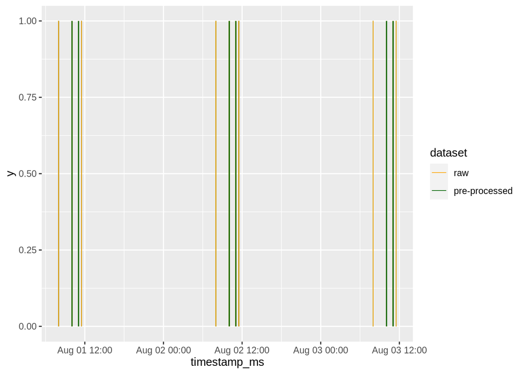

```r
ggplot(data = rfid_combined) +

  # Añade una línea vertical para cada marca de tiempo
  geom_segment(
    aes(x = timestamp_ms, y = 0, xend = timestamp_ms, yend = 1, color = dataset),
    linewidth = 0.3
  ) +

  scale_color_manual(values = c("orange", "darkgreen"))
```

En la gráfica que acabas de hacer, es muy difícil de discriminar entre las líneas para cada conjunto de datos. Puedes usar la función `facet_wrap()` para dividir los conjuntos de datos en paneles diferentes:

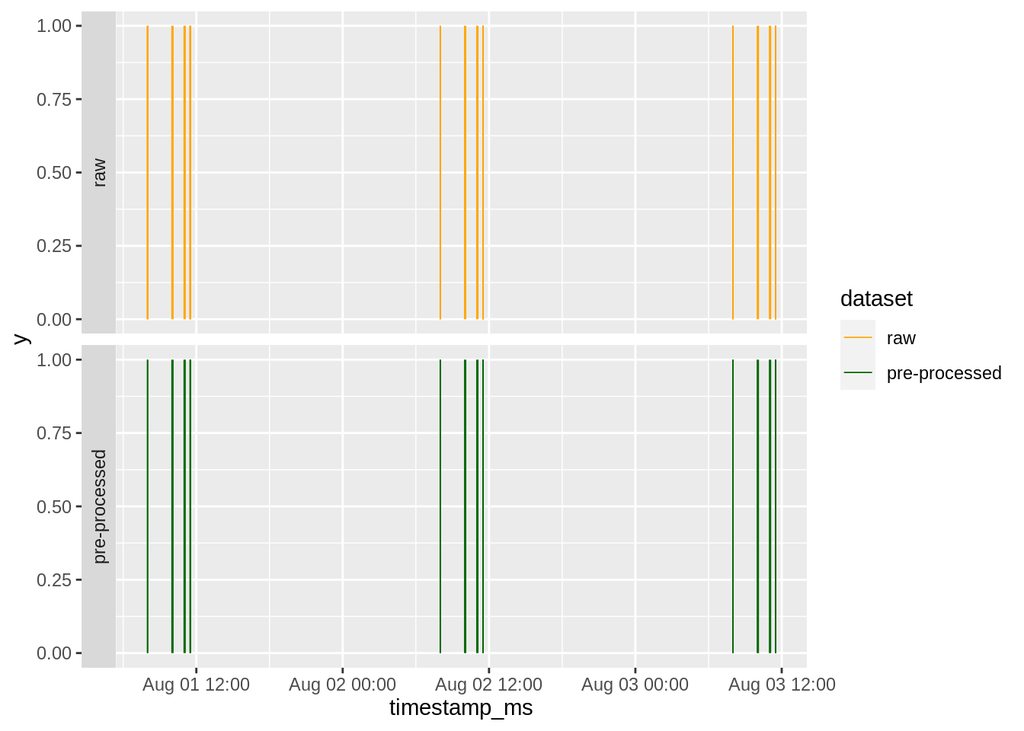

```r
ggplot(data = rfid_combined) +

  # Añade una línea vertical para cada marca de tiempo
  geom_segment(
    aes(x = timestamp_ms, y = 0, xend = timestamp_ms, yend = 1, color = dataset),
    linewidth = 0.3
  ) +

  scale_color_manual(values = c("orange", "darkgreen")) +

  # El símbolo de ~ significa "por", así que estás creando un panel por cada valor único (o categoría) en la columna dataset
  facet_wrap(~ dataset, nrow = 2, strip.position = "left")
```

Acabas de crear paneles diferentes adentro de esta gráfica y cada panel contiene datos un solo conjunto de datos. Con este cambio estructural también alineaste los paneles en el mismo eje x para que sea más fácil de comparar patrones temporales.

Desde este punto de vista es difícil ver cómo los dos conjuntos de datos (originales y procesados) son diferentes. Puedes filtrar el `dataframe` con funciones del `tidyverse` para visualizar solo las primeras dos detecciones para cada conjunto de datos:

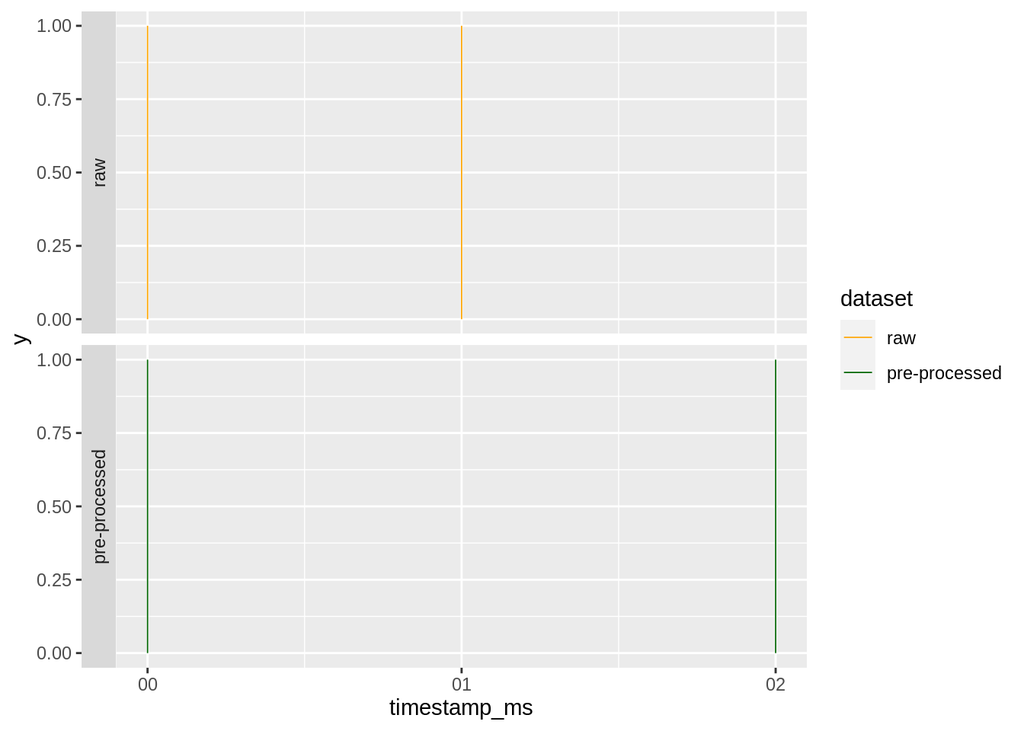

```r
ggplot(data = rfid_combined %>%
         # Crea grupos por las categorías o levels en la columna dataset
         group_by(dataset) %>%
         # Selecciona las primeras dos filas para cada grupo
         slice(1:2) %>%
         ungroup()
       ) +

  # Añade una línea vertical para cada marca de tiempo
  geom_segment(
    aes(x = timestamp_ms, y = 0, xend = timestamp_ms, yend = 1, color = dataset),
    linewidth = 0.3
  ) +

  scale_color_manual(values = c("orange", "darkgreen")) +

  # El símbolo de ~ significa "por", así que estás creando un panel por cada valor único (o categoría) en la columna dataset
  facet_wrap(~ dataset, nrow = 2, strip.position = "left")
```

Ahora deberías de ver que la segunda marca de tiempo en los datos originales se eliminó del conjunto de datos procesados (fue filtrado usando el umbral temporal en `preprocess_detections`).

Luego puedes añadir los datos de eventos de posar en el `dataframe` `rfid_perch`, que no combinaste con los otros conjuntos de datos. En cambio a `rfid_raw` y `rfid_pp`, este conjunto de datos tiene dos columnas de marcas de tiempo que contienen información sobre el inicio y el fin de cada evento de posar. Puedes añadir este conjunto de datos a la gráfica con otra llamada de la función `geom_segment()`. Usarás esta capa de `geom_segment()` para añadir líneas que contienen información temporal sobre cuándo los eventos de posar empezaron y terminaron.

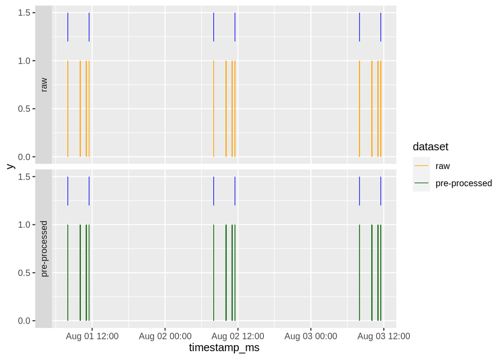

```r
ggplot(data = rfid_combined) +

  # Añade una línea vertical para cada marca de tiempo
  geom_segment(
    aes(x = timestamp_ms, y = 0, xend = timestamp_ms, yend = 1, color = dataset),
    linewidth = 0.3
  ) +

  scale_color_manual(values = c("orange", "darkgreen")) +

  # El símbolo de ~ significa "por", así que estás creando un panel por cada valor único (o categoría) en la columna dataset
  facet_wrap(~ dataset, nrow = 2, strip.position = "left") +

  # Añade los eventos de posar
  geom_segment(
    data = rfid_perch,
    aes(x = perching_start, xend = perching_end, y = 1.2, yend = 1.5),
    color = "blue",
    linewidth = 0.3
  )
```

En el código arriba para `geom_segment()`, especificaste que querías añadir otro conjunto de datos a la gráfica cuando usaste el argumento `data`. Los argumentos `x` y `y` determinan donde va a empezar cada línea en ambos ejes de la gráfica, respectivamente. También vas a tener que especificar donde quieres que cada línea termina en cada eje. En el eje x, indicaste que quieres que la línea empiece y termine cuando los eventos de posar empezaron y terminaron con proveer la columna `perching_start` al argumento `x` y `perching_end` al argumento `xend`. En el eje y, los números que usaste para los argumentos `y` y `yend` determinan donde las líneas para los eventos de posar se dibujarán, que en este caso es justamente arriba de las líneas para los otros conjuntos de datos. Las líneas para los eventos de posar se dibujaron como otra capa de información encima de cada panel de la gráfica por defecto.

Puedes hacer unos cambios a la gráfica para que sea más fácil de interpretar. Puedes cambiar la posición de la leyenda usando el argumento `legend.position` adentro de la función general de `theme()`. Abajo puedes guardar la gráfica adentro de un objeto, para que no tengas que escribir todo el código de la gráfica de nuevo cuando quieres añadirle más información.

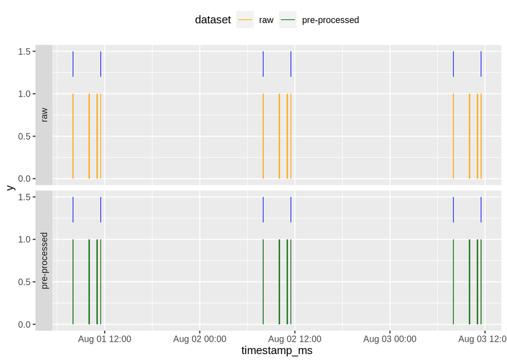

```r
gg <- ggplot(data = rfid_combined) +

  # Añade una línea vertical para cada marca de tiempo
  geom_segment(
    aes(x = timestamp_ms, y = 0, xend = timestamp_ms, yend = 1, color = dataset),
    linewidth = 0.3
  ) +

  scale_color_manual(values = c("orange", "darkgreen")) +

  # El símbolo de ~ significa "por", así que estás creando un panel por cada valor único (o categoría) en la columna dataset
  facet_wrap(~ dataset, nrow = 2, strip.position = "left") +

  # Añade los eventos de posar
  geom_segment(
    data = rfid_perch,
    aes(x = perching_start, xend = perching_end, y = 1.2, yend = 1.5),
    color = "blue",
    linewidth = 0.3
  ) +

  theme(
    legend.position = "top"
  )

gg
```

Ahora puedes hacer unos ajustes menores para seguir mejorando la gráfica, incluyendo cambiar los títulos de los ejes para que sean más informativos, cambiar el color de fondo a blanco, y eliminar el texto en el eje y tanto como las rayas en el eje y, porque este eje no contiene información para interpretación de los datos (o sea, la altura de cada línea no contiene información para interpretación).

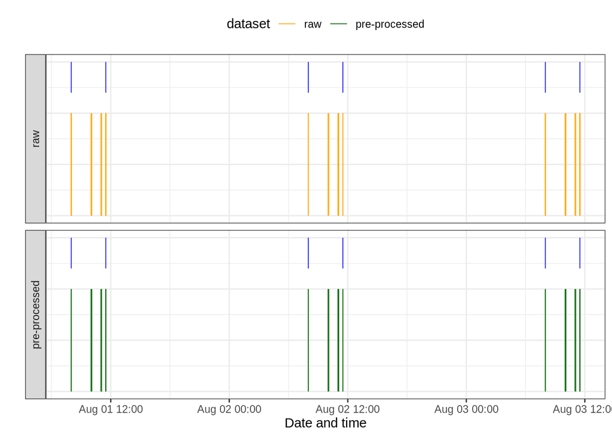

```r
gg <- gg +

  # Cambia los títulos de ambos ejes
  xlab("Date and time") +

  # El eje y no contiene información y por ende puedes eliminar este título
  ylab("") +

  # Usa esta función para cambiar el color de fondo a blanco y negro
  theme_bw() +

  # Usa funciones de estética para eliminar el texto en el eje y y también los rayos en este eje
  theme(
    axis.text.y = element_blank(),
    axis.ticks.y = element_blank(),
    legend.position = "top"
  )

gg
```

Puedes guardar las gráficas que creas en R como archivos físicos. Abajo usarás la función `ggsave()` para escribir la gráfica que hiciste arriba como un archivo en tu computadora.

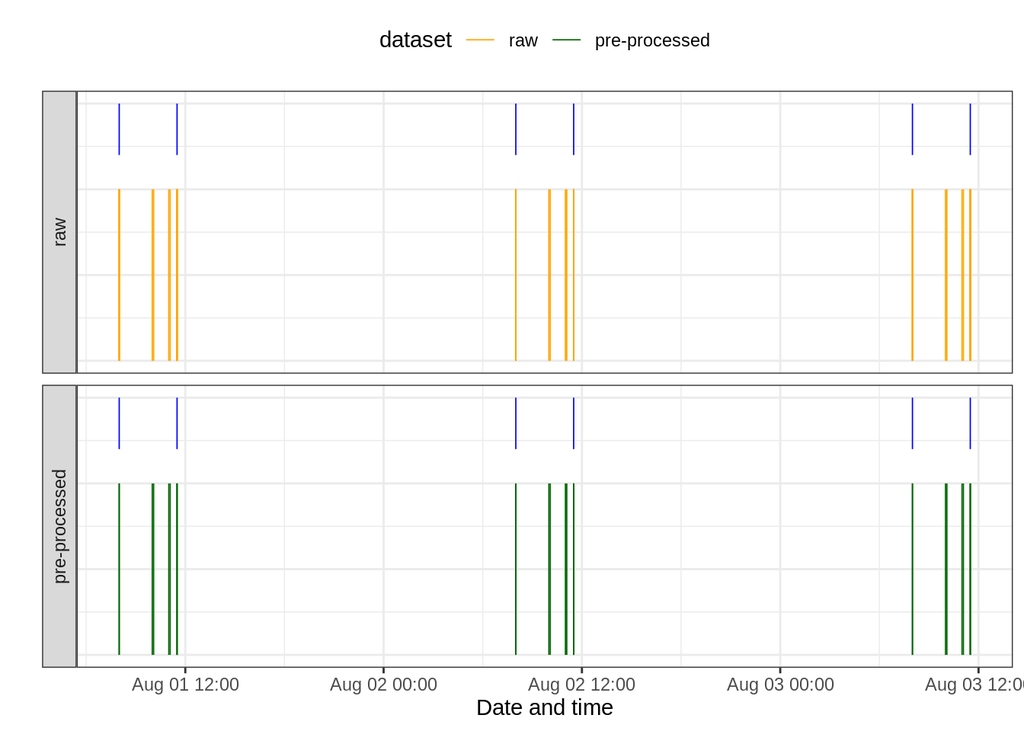

```r
gg
```

```r
# Guarda la gráfica como un archivo en tu computadora
ggsave(file.path(path, "raw_processed_perching.tiff"), width = 8, height = 6, units = "in", dpi = 300)
```

Puedes continuar con modificaciones a este archivo para crear una figura de alta calidad para una publicación. Por ejemplo, puedes cambiar el tamaño final del archivo (`width` o “el ancho”, `height` o “la altura”), tanto como la resolución en píxeles (`dpi`). También puedes cambiar el tamaño de texto en cada eje o del título de cada eje, o la posición de la leyenda mientras determinas el tamaño final de la imagen.

En el siguiente tutorial vas a continuar analizando datos con ABISSMAL y vas a crear una gráfica de código de barras más compleja y refinada.